# Dismantling Math, Stats, and CS Silos: PCMI Guidelines for Undergraduate Majors in Data Science

Thursday August 2nd, 2018

## Today’s focus

What data to use in introductory statistics and data science courses?

Ideally data that’s:

1. **Rich** enough to answer meaningful questions with
2. **Real** enough to ensure that there is context
3. **Realistic** enough to convey to the reality of much of the world’s data

## One goal

On the one hand, [Cobb (2015)](https://arxiv.org/pdf/1507.05346.pdf) argues that we should

1. “Teach through research”
2. **“Minimize prerequisites to research”**

## Another goal

On the other hand, from [New York Times](https://www.nytimes.com/2014/08/18/technology/for-big-data-scientists-hurdle-to-insights-is-janitor-work.html):

[figure not shown]

## Analogy for second goal

> love [@JennyBryan](https://twitter.com/JennyBryan?ref_src=twsrc%5Etfw)'s analogy of classroom data as teddybears & real data like a grizzly bear with salmon blood dripping out its mouth [#jsm2015](https://twitter.com/hashtag/jsm2015?src=hash&ref_src=twsrc%5Etfw)

> — sandy griffith (@sgrifter) [August 11, 2015](https://twitter.com/sgrifter/status/631150829165113344?ref_src=twsrc%5Etfw)

## Two conflicting goals

- On the one hand: Minimize prerequisites to research
- On the other: Do not betray reality of data as it exists in much of the world

## Back to analogy

In other words, a balancing act is required between:

| Data with no prerequisites needed | Data as it exists “in the wild” |
| --- | --- |

## Data “taming”

Data “taming” sets out to balance:

- On the one hand: Performing enough pre-processing so that data is accessible to R novices
- On the other: Not performing so much pre-processing as to betray the reality of data as it exists “in the wild”

## “Tame” data principles

We propose the following [“tame” data principles](http://rpubs.com/rudeboybert/fivethirtyeight_tamedata) to remove biggest hurdles R novices face:

1. Clean variable names
2. Identification variables in left-hand columns
3. Clean dates
4. Logically ordered categorical variables
5. Consistent “tidy” format

## fivethirtyeight package

In the `fivethirtyeight` R package, [Chester Ismay](https://twitter.com/old_man_chester), [Jennifer Chunn](https://twitter.com/jchunn206), and I:

- Take FiveThirtyEight’s raw article data from [GitHub](https://github.com/fivethirtyeight/data)
- **Pre-process the raw data so that it follows “tame” data principles**
- Make the tame data, documentation, and original article easily accessible via an R package

## Examples

Following examples involve code, so I suggest you follow in HTML version of slides:

1. In your browser, go to bit.ly/causeweb_tame
2. In the left-hand menu, click on “Principle 1: Clean variable names”

## Principle 1: Clean variable names

### a) Comparing raw and tamed data

- Original article: [41 Percent Of Fliers Think You’re Rude If You Recline Your Seat](https://fivethirtyeight.com/features/airplane-etiquette-recline-seat/)
- Raw CSV data: [`flying-etiquette.csv`](https://github.com/fivethirtyeight/data/blob/master/flying-etiquette-survey/)

```r
library(readr)
library(fivethirtyeight)

# Raw data: variable names are unwieldy & have spaces
flying_raw <- read_csv("https://raw.githubusercontent.com/fivethirtyeight/data/master/flying-etiquette-survey/flying-etiquette.csv")
colnames(flying_raw)[c(5, 19)]
```

```
## [1] "Do you have any children under 18?"
## [2] "In general, is itrude to bring a baby on a plane?"
```

```r
# Tamed data: corresponding variable names are cleaner
colnames(flying)[c(5, 18)]
```

```
## [1] "children_under_18" "baby"
```

### b) Why should we care?

Working with variables names that are long/unwieldy and have spaces is a tricky.

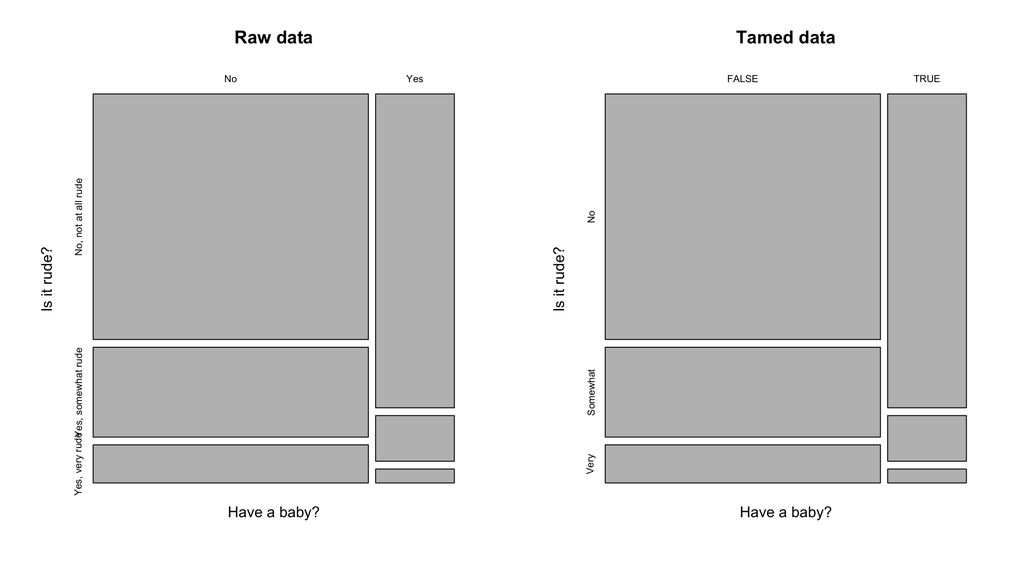

```r
mosaicplot(~ `Do you have any children under 18?` + `In general, is itrude to bring a baby on a plane?`,
           data = flying_raw,  main = "Raw data",
           xlab = "Have a baby?", ylab = "Is it rude?")
mosaicplot(~ children_under_18 + baby,
           data = flying,  main = "Tamed data",
           xlab = "Have a baby?", ylab = "Is it rude?")
```

## Principle 2: ID variables

More organizational. Any identification variables that uniquely identify the observations/rows should be place in the left-hand columns since they are of highest prominence. Such variables are used to key joins/merging of datasets.

- Original articles:
  1. [Straight Outta Compton’ Is The Rare Biopic Not About White Dudes](https://fivethirtyeight.com/features/straight-outta-compton-is-the-rare-biopic-not-about-white-dudes/)
  2. [A Statistical Analysis of the Work of Bob Ross](https://fivethirtyeight.com/features/a-statistical-analysis-of-the-work-of-bob-ross/)
- Raw CSV data:
  1. [`biopics.csv`](https://github.com/fivethirtyeight/data/tree/master/biopics)
  2. [`elements-by-episode.csv`](https://github.com/fivethirtyeight/data/tree/master/bob-ross)

```r
library(fivethirtyeight)

# Both title and imdb site tag uniquely identify movies. Show only 8 first
# columns and 3 first rows of dataset:
biopics[1:3, 1:8]
```

```
## # A tibble: 3 x 8
##   title site  country year_release box_office director number_of_subje…
##   <chr> <chr> <chr>          <int>      <dbl> <chr>               <int>
## 1 10 R… tt00… UK              1971         NA Richard…                1
## 2 12 Y… tt20… US/UK           2013   56700000 Steve M…                1
## 3 127 … tt15… US/UK           2010   18300000 Danny B…                1
## # ... with 1 more variable: subject <chr>
```

```r
# episode variable uniquely identifies episodes of "The Joy of Painting". Show
# only 8 first columns and 3 randomly chosen rows of dataset using dplyr package
library(dplyr)
bob_ross %>%
  select(1:8) %>%
  sample_n(3)
```

```
## # A tibble: 3 x 8
##   episode season episode_num title apple_frame aurora_borealis  barn beach
##   <chr>    <dbl>       <dbl> <chr>       <int>           <int> <int> <int>
## 1 S20E05      20           5 DIVI…           0               0     0     0
## 2 S23E11      23          11 FROZ…           0               0     0     0
## 3 S14E04      14           4 SNOW…           0               0     0     0
```

## Principle 3: Dates

### a) Comparing raw and tamed data

- Original article: [Some People Are Too Superstitious To Have A Baby On Friday The 13th](https://fivethirtyeight.com/features/some-people-are-too-superstitious-to-have-a-baby-on-friday-the-13th/)
- Raw CSV data: [`US_births_1994-2003_CDC_NCHS.csv`](https://github.com/fivethirtyeight/data/blob/master/births/)

```r
library(readr)
library(dplyr)
library(fivethirtyeight)

# Raw data: year, month, day are separate variables
US_births_1994_2003_raw <- read_csv("https://raw.githubusercontent.com/fivethirtyeight/data/master/births/US_births_1994-2003_CDC_NCHS.csv")
head(US_births_1994_2003_raw)
```

```
## # A tibble: 6 x 5
##    year month date_of_month day_of_week births
##   <int> <int>         <int>       <int>  <int>
## 1  1994     1             1           6   8096
## 2  1994     1             2           7   7772
## 3  1994     1             3           1  10142
## 4  1994     1             4           2  11248
## 5  1994     1             5           3  11053
## 6  1994     1             6           4  11406
```

```r
# Tamed data: variable date of type "date" included
head(US_births_1994_2003)
```

```
## # A tibble: 6 x 6
##    year month date_of_month date       day_of_week births
##   <int> <int>         <int> <date>     <ord>        <int>
## 1  1994     1             1 1994-01-01 Sat           8096
## 2  1994     1             2 1994-01-02 Sun           7772
## 3  1994     1             3 1994-01-03 Mon          10142
## 4  1994     1             4 1994-01-04 Tues         11248
## 5  1994     1             5 1994-01-05 Wed          11053
## 6  1994     1             6 1994-01-06 Thurs        11406
```

### b) Why should we care?

Without a variable of type `date`, making *time series* plots is difficult.

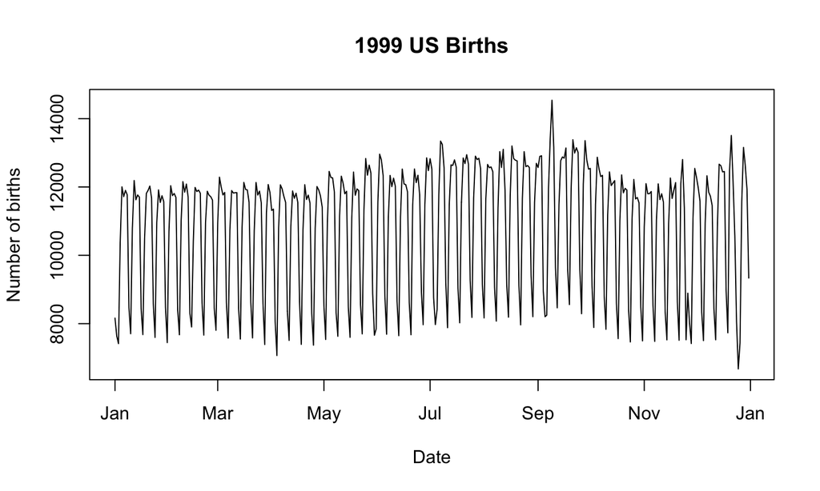

```r
# Use filter command from dplyr package for data wrangling
US_births_1999 <- US_births_1994_2003 %>%
  filter(year == 1999)

# Plot time series via base R:
plot(x = US_births_1999$date, y = US_births_1999$births, type = "l",
     xlab = "Date", ylab = "Number of births", main = "1999 US Births")
```

## Principle 4: Categorical variables

### a) Comparing raw and tamed data

- Original article: [The Dollar-And-Cents Case Against Hollywood’s Exclusion of Women](https://fivethirtyeight.com/features/the-dollar-and-cents-case-against-hollywoods-exclusion-of-women/)
- Raw CSV data: [`movies.csv`](https://github.com/fivethirtyeight/data/blob/master/bechdel/)

```r
library(readr)
library(ggplot2)
library(fivethirtyeight)
bechdel_raw <- read_csv("https://raw.githubusercontent.com/rudeboybert/fivethirtyeight/master/data-raw/bechdel/movies.csv")

# Raw data: categorical variable clean_test is saved as characters/strings
bechdel_raw$clean_test[1:5]
```

```
## [1] "notalk" "ok"     "notalk" "notalk" "men"
```

```r
# Tamed data: clean_test is saved as factor
bechdel$clean_test[1:5]
```

```
## [1] notalk ok     notalk notalk men
## Levels: nowomen < notalk < men < dubious < ok
```

### b) Why should we care?

R by default plots `characters` in alphabetical order, whereas with `factors` we can set the order of the `levels`; reordering a categorical variable/factor in R is tough, especially for new R users. In this case, we can have the bars ordered along the hierarchical nature of Bechdel test:

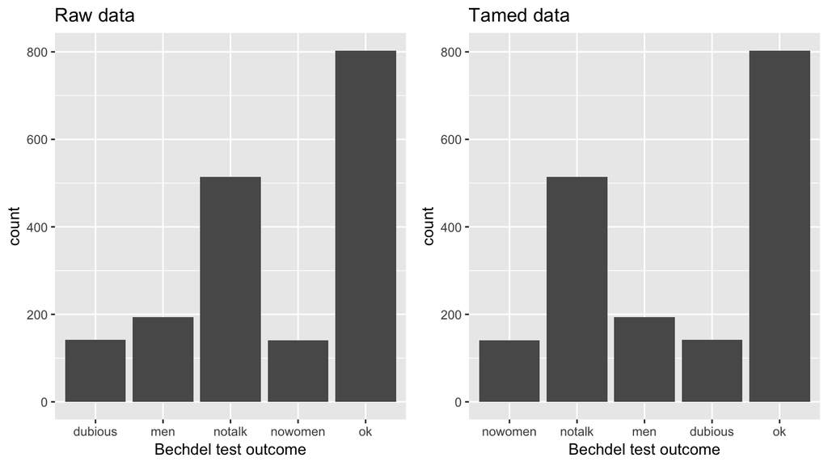

```r
# Using raw data:
ggplot(bechdel_raw, aes(x = clean_test)) +
  geom_bar() +
  labs(x = "Bechdel test outcome", y = "count", title = "Raw data")

# Using tamed data:
ggplot(bechdel, aes(x = clean_test)) +
  geom_bar() +
  labs(x = "Bechdel test outcome", y = "count", title = "Tamed data")
```

## Principle 5: “Tidy” data format

[“Tidy”](http://r4ds.had.co.nz/tidy-data.html) data format is [narrow/long](https://en.wikipedia.org/wiki/Wide_and_narrow_data) format, as opposed to wide. This format is chosen for input/output data frame standardization across many R packages in the [tidyverse](https://www.tidyverse.org/): `ggplot2`, `dplyr`, etc. There are three interrelated rules which make a dataset “tidy”:

1. Each variable must have its own column.
2. Each observation must have its own row.
3. Each value must have its own cell.

[figure not shown]

### a) Comparing raw and tamed data

- Original article: [Dear Mona Followup: Where Do People Drink The Most Beer, Wine And Spirits?](https://fivethirtyeight.com/features/dear-mona-followup-where-do-people-drink-the-most-beer-wine-and-spirits/)
- Raw CSV data: [`drinks.csv`](https://github.com/fivethirtyeight/data/blob/master/alcohol-consumption/)

```r
library(dplyr)
library(ggplot2)
library(fivethirtyeight)

# In fivethirtyeight package drinks data is kept in original non-tidy (wide) format
head(drinks)
```

```
## # A tibble: 6 x 5
##   country   beer_servings spirit_servings wine_servings total_litres_of_p…
##   <chr>             <int>           <int>         <int>              <dbl>
## 1 Afghanis…             0               0             0                0
## 2 Albania              89             132            54                4.9
## 3 Algeria              25               0            14                0.7
## 4 Andorra             245             138           312               12.4
## 5 Angola              217              57            45                5.9
## 6 Antigua …           102             128            45                4.9
```

```r
# tidyr::gather() code to convert to tidy format in help file: ?drinks
library(tidyr)
drinks_tidy <- drinks %>%
  gather(type, servings, -c(country, total_litres_of_pure_alcohol)) %>%
  arrange(country)
head(drinks_tidy)
```

```
## # A tibble: 6 x 4
##   country     total_litres_of_pure_alcohol type            servings
##   <chr>                              <dbl> <chr>              <int>
## 1 Afghanistan                          0   beer_servings          0
## 2 Afghanistan                          0   spirit_servings        0
## 3 Afghanistan                          0   wine_servings          0
## 4 Albania                              4.9 beer_servings         89
## 5 Albania                              4.9 spirit_servings      132
## 6 Albania                              4.9 wine_servings         54
```

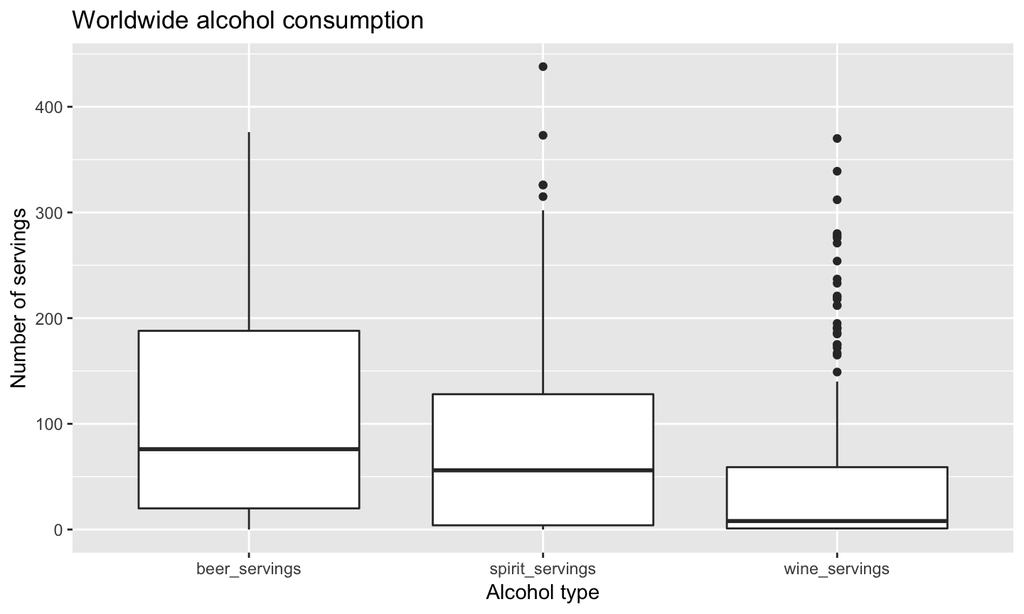

```r
ggplot(drinks_tidy, aes(x = type, y = servings)) +
  geom_boxplot() +
  labs(x = "Alcohol type", y = "Number of servings", title = "Worldwide alcohol consumption")
```

## Advanced example

### a) Comparing raw and tamed data

- Original article: [The Last 10 Weeks Of 2016 Campaign Stops In One Handy Gif](https://fivethirtyeight.com/features/the-last-10-weeks-of-2016-campaign-stops-in-one-handy-gif/)
- [Raw CSV data](https://github.com/fivethirtyeight/data/tree/master/presidential-campaign-trail) were in two separate CSVs
  - `clinton.csv`
  - `trump.csv`

In the tamed `pres_2016_trail` data frame we:

1. Ensured `lat` and `lng` were in numerical format, not in degree/minute/second, North/South, and East/West format (A variation on Principle 3: Dates)
2. Combined both CSV’s into one and added variable `candidate` (Principle 5: Tidy data format)

```r
library(dplyr)
library(fivethirtyeight)

# Tamed data:
pres_2016_trail %>%
  arrange(date) %>%
  head()
```

```
## # A tibble: 6 x 5
##   candidate date       location             lat   lng
##   <chr>     <date>     <chr>              <dbl> <dbl>
## 1 Trump     2016-09-01 Wilmington, OH      39.4 -83.8
## 2 Trump     2016-09-03 Detroit, MI         42.3 -83.0
## 3 Clinton   2016-09-05 Cleveland, Ohio     41.5 -81.7
## 4 Clinton   2016-09-05 Hampton, Illinois   41.6 -90.4
## 5 Clinton   2016-09-06 Tampa, Florida      28.0 -82.5
## 6 Trump     2016-09-06 Virginia Beach, VA  36.9 -76.0
```

### b) Why should we care?

So we can easily create a faceted map!

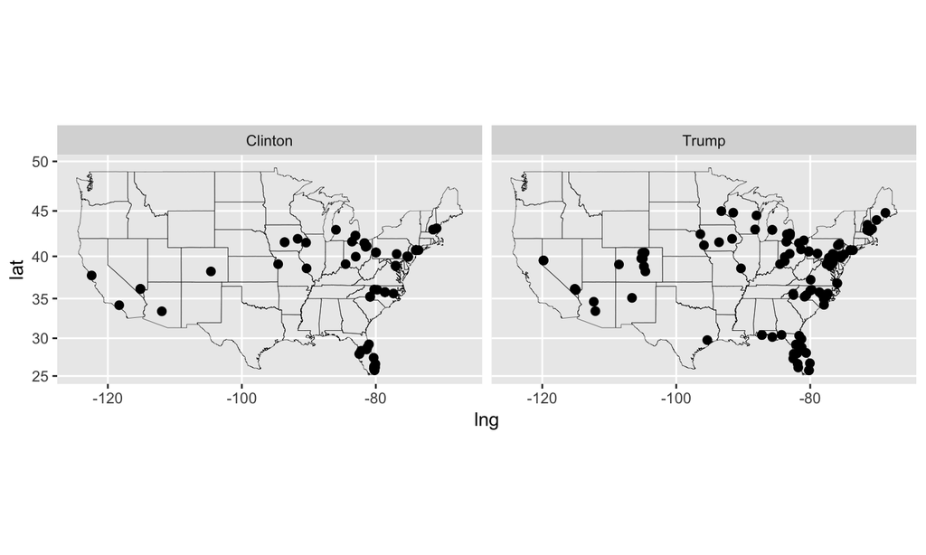

```r
library(ggplot2)
library(maps)
ggplot(data = pres_2016_trail, aes(x = lng, y = lat)) +
  facet_wrap(~candidate) +
  geom_point(col = "black", size = 2) +
  coord_map() +
  # Override data & aes()thetic mapping set above to trace path of state outlines:
  geom_path(data = map_data("state"), aes(x = long, y = lat, group = group), size = 0.1)
```

## Comments

- Analogy I heard that I like: `fivethirtyeight` is like a data petting zoo
- No “universal” balance of two goals: it will vary depending on your students’ experience, requirements, and needs
- Tame data principles and `fivethirtyeight` can be used in other contexts: 1) intermediate-level data science courses and 2) advanced projects

## Used in data science courses

1. Recruited STAT231 Data Science students to “tame” datasets STAT135 Intro students found for their final projects
2. Available on GitHub: data wrangling source code by package authors to convert 538 raw CSV data to “tamed” format [`process_data_sets_albert.R`](https://github.com/rudeboybert/fivethirtyeight/blob/master/data-raw/process_data_sets_albert.R), [`process_data_sets_chester.R`](https://github.com/rudeboybert/fivethirtyeight/blob/master/data-raw/process_data_sets_chester.R), [`process_data_sets_jen.R`](https://github.com/rudeboybert/fivethirtyeight/blob/master/data-raw/process_data_sets_jen.R)

## Used for advanced projects

- `fivethirtyeight` package is in maintenance mode: no new development, only need to add new datasets
- Get student interns to do it instead!
- Internship model of learning/development: learning [R package construction](http://r-pkgs.had.co.nz/), [GitHub](http://happygitwithr.com/), communication and project management skills, etc. RStudio’s 2018 [`broom` package summer internship](https://blog.rstudio.com/2018/04/18/summer-interns/) follows a similar model.
- **Undergraduate student** written data wrangling source code to convert 538 raw CSV data to “tamed” format [`process_data_sets_maggie.R`](https://github.com/rudeboybert/fivethirtyeight/blob/master/data-raw/process_data_sets_maggie.R), [`process_data_sets_meredith.R`](https://github.com/rudeboybert/fivethirtyeight/blob/master/data-raw/process_data_sets_meredith.R)

## Other resources

- Complete TISE article ([HTML](http://rpubs.com/rudeboybert/fivethirtyeight_tamedata), [PDF](https://escholarship.org/uc/item/0rx1231m#main))
- Package [homepage](https://fivethirtyeight-r.netlify.com/articles/fivethirtyeight.html) including list of all datasets
- Link to this presentation bit.ly/causeweb_tame